# Confidence Intervals

Leandro Ledesma

2024-03-03

The following document is heavily inspired by Chapter 6: Confidence Intervals from Statistics Unplugged 4th Edition (2013) by Sally Caldwell and Chapter 5: Foundations for inference from OpenIntro Statistics 4th Edition (2019) by David Diez. To make sense of the following information, a good understanding of the Central Limit Theorem is a must. We will be covering this concept again in this document, however, for a much more indepth guide to the Central Limit Theorem, please visit the prior page.

### Quick background knowledge

In inferential statistics, the goal is to make inferences about the parameters of a populations based on the statistics from its sample. We know already that a sample (if selected randomly) is highly likely to produce statistics that are similar to the parameters of the population. For example, if we think back to the sampling distribution of sample means, we know that if we collect a thousand samples with a sample size of 40 from a population, calculate their means, and graph them as a histogram, that most of the sample means will be fairly close to the population mean. In addition, if this was to be done an infinite number of times, two things become certain.

1. The mean of the sample means will be exactly the same as the mean of the population.
2. The standard deviation of the sampling distribution (Standard error) will be equal to the standard deviation of the population divided by the square root of the sample size.

Now some may be asking, what is standard error? If this is you please go back and re-read the document on the Central Limit Theorem. For a quick refresher, the standard error is a measurement of the average error of sample means estimating the population mean. It is a fairly small distribution, but normal nonetheless, thus uses the same rules that underline z-distributions. We will come back to this later.

### Confidence Interval

So then, what is a confidence interval? A confidence interval is a statisticians best way to identifying what the true population mean is. Cutting directly to the point, because samples will always provide statistics that vary from each other, and because they frequently are not equivalent to the population parameter, but instead close to it, then the best we can do is not provide one number, but instead provide two! These two numbers will function as a range, and in that range, it will be very likely that the true population mean will be present.

Now let’s get some jargon out of the way. When discussing confidence interval, our starting point is always the statistic of the sample, in this case it will be the mean. This value will be called the **point estimate**. Again think of this as your starting point to identifying what the true population mean is. The next thing we need to think about is constructing a range around our point estimate (mean of our sample). This range will then determine (to a degree) a possible location of where the true population mean is. It is very likely that it is somewhere in there but we can NEVER be sure what it will be exactly. And a lot of times, we don’t really need to know it either.

### The degree of confidence behind a confidence interval

A confidence interval gets its name for two reasons. The first is the interval portion, which implies that there will be two values which will create a range or an interval that will very likely contain the true population parameter withing it. The next part of the name is the confidence We can actually modify what our degree of confidence is. For example, in research the two commonly used confidence intervals are 95% confidence and 99% confidence. In 95% confidence intervals, we are essentially calculating two values the cushion the point estimate and within this range we are 95% confident that the population mean is located somewhere there. For 99% confidence intervals, this same logic applies, we calculate two values that cushion our point estimate and within this range we are 99% confident that the true population parameter is within it.

The two values calculated for a 95% confidence interval and the two values calculate for a 99% confidence interval are not going to be the same but will be similar. The values for the latter will produce a larger interval/range, and this make sense since by doing so we can increase our confidence that our population parameter will be present. So while the pro to choosing a larger interval is higher accuracy, think about it, if I say that someone for a test scored between 0-100, the accuracy/likelihood of this being correct is essentially 100%, however, the con is that my **precision** will be lower.

### Confidence Interval Problem Types

We are getting a better understanding conceptually of what a confidence interval is and what is its function. To solidify this concept we should start by creating some examples and following through with the math that is involved. There are three types of problems that you would be asked on homework questions of tests in relation to confidence intervals. These would be on the following:

1. Confidence intervals in relation to z-distributions
2. Confidence intervals in relation to t-distributions
3. Confidence intervals in relation to proportions

### Confidence intervals with a known population standard deviation

When I first heard about this, I was very confused and you might be too. Why would we learn about confidence intervals that relate to a population with a known standard deviation. Wasn’t the point of inferential statistics to infer about the population from a sample because we do not know anything about the population, including its standard deviation? Well yea, but most of the time not always. As mentioned in Statistics Unplugged 4th Edition (2013), there are cases where the standard deviation of a population is known and having a good concept of this type of confidence interval problem will make the others easier to understand.

So in what cases are the standard deviation of a population known? Well, in standardized tests, the standard deviation is already known. For example, in standardized tests like the GRE, the creators of these test have devised it to be at a certain difficulty where the average person who takes the test will score a 150. This average can be converted into a percentile of 50%, using the same principles of the z-distribution. Additionally the standard deviation is also known, which for the verbal subtest is 8.5. Now that we know the standard deviation (by using Google) from the population (all GRE verbal test takers), we can use it to calculate the standard error. The standard error is the measure that we use to construct our confidence interval, so calculating it is the first thing that we will always have to do. All notation below is from Statistics Unplugged 4th Edition (2013).

The formula below shows how to do that when the population standard deviation is known.

$$\begin{align*}
\sigma_{\overline{X}} =\frac{\sigma}{\sqrt{n}}
\end{align*}$$

So then for our concrete example, let’s say we got a sample of 45 test takers that got an average score of 148 for the verbal test. This will be our point estimate. Next we will need to calculate the standard error.

$$\begin{align*}
\sigma_{\overline{X}} =\frac{8.5}{\sqrt{45}} = 1.26
\end{align*}$$

Now that we have the statistics that we need:

sample mean ($\overline{X}$)= 148

standard error ($\sigma_{\overline{X}}$)= 1.26

We can start the calculation of the confidence interval which is the following:

$$\begin{align*}
CI = \overline{X} \pm Z*\sigma_{\overline{X}}
\end{align*}$$

The confidence interval equation now requires our final value. Which is the z-value. Since our example includes a standard deviation of the population, then our estimated standard error will belong to a normal distribution (z-distribution), thus we can apply the knowledge from that distribution to our example. If we are interested in constructing a confidence interval of 95%, which will produce two values around our point estimate that will have a 95% likelihood that the population parameter is present, then we can rely on the z-values 1.96. This is common knowledge and something that should memorized. The z-value 1.96, which is very close to the number 2, contain 95% of all scores in a normal distribution. For more information on this, please look at the z-distribution document. With this last piece of information out of the way, we can now calculate our confidence interval.

$$\begin{align*}
CI = 148 \pm 1.96 * 1.26 = c(145.5, 150.5)
\end{align*}$$

And there we go, we can now say the following: We are 95% confident that the true population mean is between 145.5 and 150.5. And in this cases, it just so happened to be true. However, it is very easy for some of you to say, well you chose the number 148 knowing in advance that it would produce a confidence interval between 145.5 and 150.5, which is happened to contain the true population mean of 150. This is not proof. And interestingly, you would be correct. So now the question is how can we prove this instead of taking this example at face value?

### Universal block code settings

```r
knitr::opts_chunk$set(echo = TRUE)
knitr::opts_chunk$set(message = FALSE)
knitr::opts_chunk$set(comment = NULL)
```

### Load in the data manipulation packages first

```r
library(tidyverse)
library(ggplot2)
library(ggpubr)
library(kableExtra)
```

### 95% Confidence Interval with a known population standard deviation (Proof)

The explanation from above utilized information about a population and a single sample. Fortunately, we can produce similar results by creating a population of scores with an established mean and standard deviation. Then we will take one hundred samples and see how well the confidence interval for each sample captures the population mean. Let’s do so using the same numbers as above. So we will create a population of scores with a mean score of 150 and a standard deviation of 8.5. Since this is a population of scores that is standardized, it will follow a z-distribution, aka a normal distribution curve.

```r
# Set a seed
set.seed(123)

# Create a population
population.scores <- rnorm(n = 341574,
                           mean = 150,
                           sd = 8.5)
```

Now we will take 100 samples from our population. Each sample will have 45 scores.

```r
# Taking samples
samples.list <- list()

for(ii in 1:100) {

 samples.list[[ii]] <- sample(x = population.scores,
                              size = 45,
                              replace = TRUE)

}

# Obtain the means of each sample
sample.means <- samples.list %>%
  sapply(., function(x) mean(x))
```

Each mean will function as a point estimate. Since we know the standard deviation of the population, we will now calculate it using the formula from above.

```r
# Calculating the standard error
se = sd(population.scores)/sqrt(45)
```

The next step is to choose our z-value. Since we have information on the standard deviation of the population, then the standard error given is that of a normal distribution, which is the z-distribution. We know already that 95% of all scores are within 1.96 z-scores away from the mean. Thus, we will use this value since we want to calculate a 95% confidence interval. If we wanted to calculate a confidence interval that was not 95%, then we would use a different z-value.

```r
# Setting our z score
z.score <- 1.96
```

Now that we have all components needed to calculate a 95% confidence interval, we can use the equation from above. Again, we are trying to solve for two values around our point estimate. Now, we do not have one point estimate, but this time we have 100, because we took 100 samples of 45 scores and each one has a mean. Thus, each mean will have their own two values that represents the 95% confidence interval.

```r
# Calculate the confidence intervals
confidence.interval.values <- data.frame(sample.means = sample.means) %>%
  mutate(lower.bound = sample.means - (z.score * se),
         upper.bound = sample.means + (z.score * se))

# View what the datafame looks like
head(confidence.interval.values)
```

```
  sample.means lower.bound upper.bound
1     150.9871    148.4998    153.4744
2     150.3667    147.8794    152.8540
3     150.1514    147.6641    152.6387
4     150.2067    147.7194    152.6940
5     150.6833    148.1959    153.1706
6     149.9120    147.4247    152.3993
```

### Assessing the accuracy

We know what the population mean is. It is 150, thus we can now verify for ourselves in the graph below the number of samples that were able to capture the true mean.

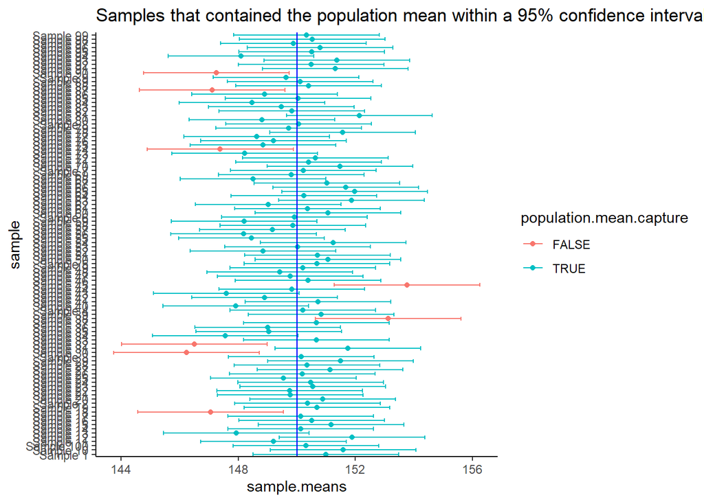

```
[1] "From our 100 sample means, 92 captured the true population mean within their 95% confidence interval."
```

```r
# Add the population mean into the 95% CF data frame
confidence.interval.values <- confidence.interval.values %>%
  mutate(sample = paste("Sample",1:nrow(confidence.interval.values)),
         population.mean = 150,
         population.mean.capture =  between(x = population.mean,
                                            left = lower.bound,
                                            right = upper.bound))

# Plot the graph
confidence.interval.values %>%
  ggplot(aes(x = sample, y = sample.means, color = population.mean.capture)) +
  geom_point() +
  geom_errorbar(aes(ymin = lower.bound, ymax = upper.bound)) +
  coord_flip() +
  geom_hline(yintercept = 150,
             color = "blue") +
  labs(title = "Samples that contained the population mean within a 95% confidence interval") +
  theme_classic()
```

### 99% Confidence Inteval with with a known population standard deviation (Proof)

```r
# Setting our z score
z.score <- 2.58
```

```r
# Calculate the confidence intervals
confidence.interval.values <- data.frame(sample.means = sample.means) %>%
  mutate(lower.bound = sample.means - (z.score * se),
         upper.bound = sample.means + (z.score * se))

# View what the datafame looks like
head(confidence.interval.values)
```

```
  sample.means lower.bound upper.bound
1     150.9871    147.7130    154.2612
2     150.3667    147.0926    153.6408
3     150.1514    146.8773    153.4255
4     150.2067    146.9326    153.4808
5     150.6833    147.4091    153.9574
6     149.9120    146.6379    153.1861
```

### Assessing the accuracy

We know what the population mean is. It is 150, thus we can now verify for ourselves in the graph below the number of samples that were able to capture the true mean.

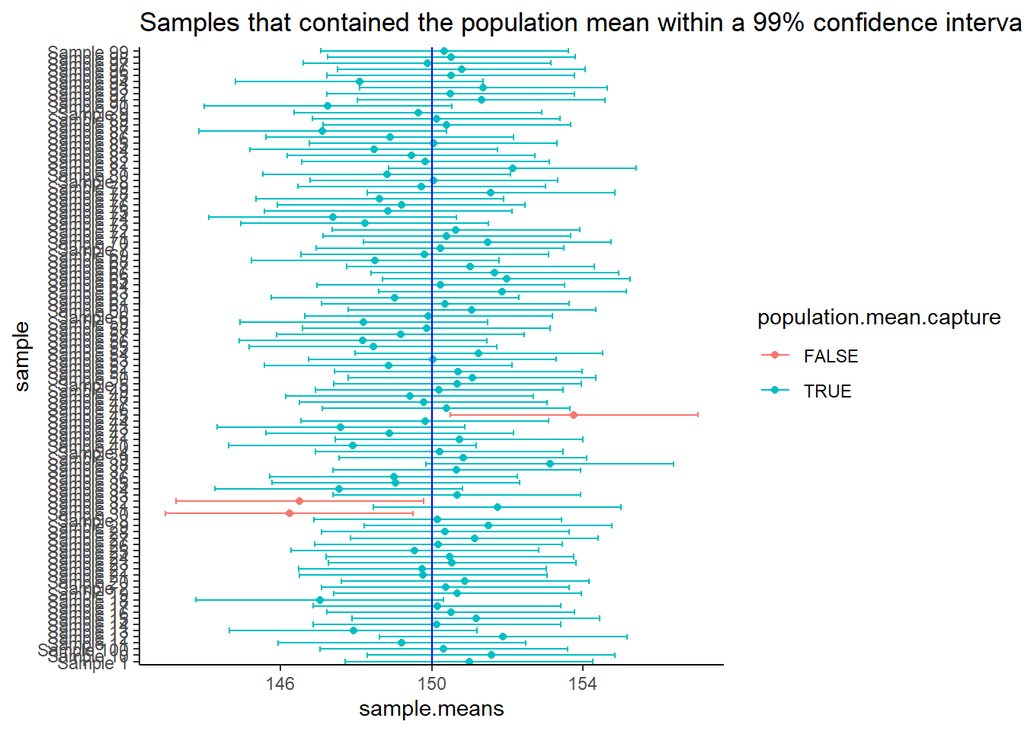

```
[1] "From our 100 sample means, 97 captured the true population mean within their 99% confidence interval."
```

```r
# Add the population mean into the 95% CF data frame
confidence.interval.values <- confidence.interval.values %>%
  mutate(sample = paste("Sample",1:nrow(confidence.interval.values)),
         population.mean = 150,
         population.mean.capture =  between(x = population.mean,
                                            left = lower.bound,
                                            right = upper.bound))

# Plot the graph
confidence.interval.values %>%
  ggplot(aes(x = sample, y = sample.means, color = population.mean.capture)) +
  geom_point() +
  geom_errorbar(aes(ymin = lower.bound, ymax = upper.bound)) +
  coord_flip() +
  geom_hline(yintercept = 150,
             color = "blue") +
  labs(title = "Samples that contained the population mean within a 99% confidence interval") +
  theme_classic()
```

### Confidence Interval without a population standard deviation

The examples from above are a good practice for most problems that you are likely to encounter in your homework since they follow the principles of normally distributed curves. However, in most cases, we will not have the luxury of using such techniques. This is because without the standard deviation of a population, we can only estimate a standard error that will come from a curve that is **NOT** normally distributed. In these cases, we essentially follow the same steps above, except we do not rely on the z-values when calculating our confidence intervals. Instead, we will need to used a special table with t-values. This is because the distribution that our estimated standard error is coming from will be flatter than that of a normal curve, and when a curve is flatter, the standard deviation values that contain 95% of the area under the curve become more spread out. Therefore, t-distribution curves take this into account. The way they work are pretty simple, we first look at our sample size, for our new example we will have a sample size of 30 and then subtract one from it (n-1). This represents our **degrees of freedom (df)**. To explain this concept briefly, anytime we have to estimate a value that is unknown, in this case we are estimating the standard deviation of the population from our sample, we have n-1 values that are free to vary. Thus, we need to use this rule to pick the proper row in the Family of t Distributions (two-tailed). Next are the columns. There are columns named Level of Significance that range from .20 - .001. Essentially, taking this value and subtracting it from 1 will give us information abut the confidence interval that we are interested in. We want to know what t-value to use for a 95% confidence interval, so the column with .05 (1-.95 = .05) will give us that information. The t-value that we get from our 29 df (30-1) row and .05 (95% confidence) column is 2.045. With this, let’s recreate our example from above.

Additionally the notation for the standard error also changes so please be mindful of this.

$$\begin{align*}
S_{\overline{X}} = \frac{s}{\sqrt{n}}
\end{align*}$$

Now we will take 100 samples from our population. Each sample will have 30 scores.

```r
# Taking samples
samples.list <- list()

for(ii in 1:100) {

 samples.list[[ii]] <- sample(x = population.scores,
                              size = 30,
                              replace = TRUE)

}

# Obtain the means of each sample
sample.means <- samples.list %>%
  sapply(., function(x) mean(x))
```

Each mean will function as a point estimate. Since we know the standard deviation of the population, we will now calculate it using the formula from above. However, keep in mind this time the standard error is **NOT** coming from a normal distribution.

```r
# Calculating the standard error
se = sd(population.scores)/sqrt(30)
```

```r
# Setting our z score
t.score <- 2.045
```

```r
# Calculate the confidence intervals
confidence.interval.values <- data.frame(sample.means = sample.means) %>%
  mutate(lower.bound = sample.means - (t.score * se),
         upper.bound = sample.means + (t.score * se))

# View what the datafame looks like
head(confidence.interval.values)
```

```
  sample.means lower.bound upper.bound
1     152.7190    149.5406    155.8974
2     152.6369    149.4584    155.8153
3     149.7441    146.5657    152.9225
4     151.2202    148.0418    154.3986
5     149.5287    146.3503    152.7071
6     148.5807    145.4023    151.7591
```

### Assessing the accuracy

We know what the population mean is. It is 150, thus we can now verify for ourselves in the graph below the number of samples that were able to capture the true mean.

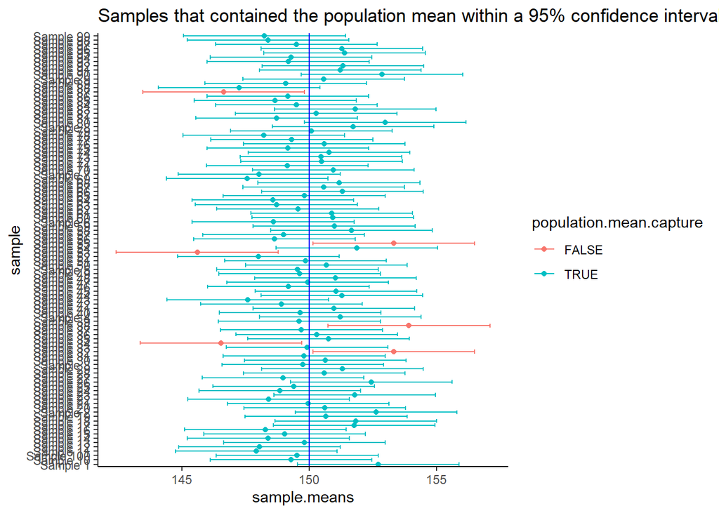

```
[1] "From our 100 sample means, 94 captured the true population mean within their 95% confidence interval."
```

```r
# Add the population mean into the 95% CF data frame
confidence.interval.values <- confidence.interval.values %>%
  mutate(sample = paste("Sample",1:nrow(confidence.interval.values)),
         population.mean = 150,
         population.mean.capture =  between(x = population.mean,
                                            left = lower.bound,
                                            right = upper.bound))

# Plot the graph
confidence.interval.values %>%
  ggplot(aes(x = sample, y = sample.means, color = population.mean.capture)) +
  geom_point() +
  geom_errorbar(aes(ymin = lower.bound, ymax = upper.bound)) +
  coord_flip() +
  geom_hline(yintercept = 150,
             color = "blue") +
  labs(title = "Samples that contained the population mean within a 95% confidence interval") +
  theme_classic()
```